# 5.2 Enriched pTAI GO analysis

# Gene Ontology (GO) enrichment

## Top 100 TAI genes

Based on the top 100 contributors to TAI, we can assess whether certain GO categories are enriched. We use `Fisher’s exact` test statistics with the `parent-child algorithm` as implemented in `TopGO`. [Note, the enrichment analysis per se was not possible but the GO terms on each gene was analysed]

```r
# library(ggfortify)
library(tximport)
library(myTAI)
# library(topGO)
library(tidyverse)
```

## Load data

### Load intersections

```r
Ec_PES_32m_unicell <- readr::read_csv("data/pTAI/Ec_PES_32m_unicell.csv")
Ec_PES_25f_unicell <- readr::read_csv("data/pTAI/Ec_PES_25f_unicell.csv")
Ec_PES_32m.sqrt_unicell <- readr::read_csv("data/pTAI/Ec_PES_32m.sqrt_unicell.csv")
Ec_PES_25f.sqrt_unicell <- readr::read_csv("data/pTAI/Ec_PES_25f.sqrt_unicell.csv")
Ec_PES_32m.log2_unicell <- readr::read_csv("data/pTAI/Ec_PES_32m.log2_unicell.csv")
Ec_PES_25f.log2_unicell <- readr::read_csv("data/pTAI/Ec_PES_25f.log2_unicell.csv")
Ec_PES_32m.rank_unicell <- readr::read_csv("data/pTAI/Ec_PES_32m.rank_unicell.csv")
Ec_PES_25f.rank_unicell <- readr::read_csv("data/pTAI/Ec_PES_25f.rank_unicell.csv")
Ec_PES_32m.rlog_unicell <- readr::read_csv("data/pTAI/Ec_PES_32m.rlog_unicell.csv")
Ec_PES_25f.rlog_unicell <- readr::read_csv("data/pTAI/Ec_PES_25f.rlog_unicell.csv")
# Ec_PES_32m_denoised_unicell <- readr::read_csv("data/pTAI/Ec_PES_32m_denoised_unicell.csv")
# Ec_PES_25f_denoised_unicell <- readr::read_csv("data/pTAI/Ec_PES_25f_denoised_unicell.csv")
# Ec_PES_32m.sqrt_denoised_unicell <- readr::read_csv("data/pTAI/Ec_PES_32m.sqrt_denoised_unicell.csv")
# Ec_PES_25f.sqrt_denoised_unicell <- readr::read_csv("data/pTAI/Ec_PES_25f.sqrt_denoised_unicell.csv")
# Ec_PES_32m.log2_denoised_unicell <- readr::read_csv("data/pTAI/Ec_PES_32m.log2_denoised_unicell.csv")
# Ec_PES_25f.log2_denoised_unicell <- readr::read_csv("data/pTAI/Ec_PES_25f.log2_denoised_unicell.csv")
```

### Load PES

```r
# Non-transformed
Ec_PES_32m <-
  readr::read_csv(file = "data/Ec_PES_32m.csv")
Ec_PES_25f <-
  readr::read_csv(file = "data/Ec_PES_25f.csv")
# sqrt-tranformed
Ec_PES_32m.sqrt <-
  readr::read_csv(file = "data/Ec_PES_32m.sqrt.csv")
Ec_PES_25f.sqrt <-
  readr::read_csv(file = "data/Ec_PES_25f.sqrt.csv")
# log2-tranformed
Ec_PES_32m.log2 <-
  readr::read_csv(file = "data/Ec_PES_32m.log2.csv")
Ec_PES_25f.log2 <-
  readr::read_csv(file = "data/Ec_PES_25f.log2.csv")
# rank-tranformed
Ec_PES_32m.rank <-
  readr::read_csv(file = "data/Ec_PES_32m.rank.csv")
Ec_PES_25f.rank <-
  readr::read_csv(file = "data/Ec_PES_25f.rank.csv")
# rlog-tranformed
Ec_PES_32m.rlog <-
  readr::read_csv(file = "data/Ec_PES_32m.rlog.csv")
Ec_PES_25f.rlog <-
  readr::read_csv(file = "data/Ec_PES_25f.rlog.csv")
# Fs_LRT.1000 <-
#   readr::read_csv("data/Fs_LRT_1000.csv")
# Fd_LRT.1000 <-
#   readr::read_csv("data/Fd_LRT_1000.csv")
```

```r
# similar to unicellular_pMat() from 2_4_unicell_pTAI.Rmd
process_pMat <- function(PES, dropzero = F, ordered_stages, top_genes = F, n_genes = 100, stage_select = "gamete"){

        if(!is.data.frame(PES))
                stop("PES is not a dataframe")

        stage_select <- rlang::sym(stage_select)

        PES_filt <- PES

        PES_filt <- PES_filt %>%
                myTAI::pMatrix() %>%
                tibble::as_tibble(rownames = "GeneID")

        # in case one wants to select the top N genes.
        if(top_genes){
                PES_filt <- PES_filt %>%
                        dplyr::slice_max({{stage_select}}, n = n_genes)
        }

        PES_filt <- PES_filt %>%
                tidyr::pivot_longer(!GeneID, names_to = "Stage", values_to = "pTAI")

        # make factor
        PES_filt$Stage <- base::factor(PES_filt$Stage, ordered_stages)
        return(PES_filt)
}
```

### Load interproscan data

```r
GO_Ec <- read_delim("data/Interproscan/Ec_ips/Ectocarpus-sp7.filt.processed.faa.tsv",
                    delim = "\t", col_select = c(1,14)) %>%
        drop_na() %>%
        filter(GO_term != "-") %>%
        separate_rows(GO_term, sep = "\\|") %>%
        # dplyr::mutate(GeneID = str_remove(GeneID, "\\.[^.]+$")) %>%
        arrange(GeneID) %>%
        distinct()
IPR_Ec <- read_delim("data/Interproscan/Ec_ips/Ectocarpus-sp7.filt.processed.faa.tsv",
                    delim = "\t") %>%
        dplyr::select(GeneID, Analysis, Signature_description, GO_term) %>%
        # dplyr::mutate(GeneID = str_remove(GeneID, "\\.[^.]+$")) %>%
        arrange(GeneID) %>%
        distinct()
length(unique(GO_Ec$GO_term))
length(unique(GO_Ec$GeneID))
```

There are 18,289 GO terms (whereof 2070 are unique) attached to 9881 genes (including isoforms) in *Ectocarpus*.

# GO×Top100pTAI analysis

## Ectocarpus

### raw TPM

```r
GO_Ec %>% dplyr::filter(GeneID %in% Ec_PES_32m_unicell$GeneID)
```

| GeneID | GO_term |
| --- | --- |
| Ec-07_001470.1 | GO:0009765 |
| Ec-07_001470.1 | GO:0016020 |
| Ec-20_001230.1 | GO:0046872 |
| Ec-21_005870.1 | GO:0071203 |
| Ec-22_003700.1 | GO:0016813 |
| Ec-22_003700.1 | GO:0046872 |

```r
Ec_PES_32m %>% dplyr::filter(GeneID %in% Ec_PES_32m_unicell$GeneID) %>% dplyr::select(Phylostratum, GeneID)
```

| Phylostratum | GeneID |
| --- | --- |
| 11 | Ec-00_006310.1 |
| 11 | Ec-00_010730.1 |
| 7 | Ec-01_002550.1 |
| 6 | Ec-01_003340.1 |
| 11 | Ec-03_003690.1 |
| 8 | Ec-06_001200.1 |
| 11 | Ec-06_003350.3 |
| 1 | Ec-07_001470.1 |
| 7 | Ec-07_005530.1 |
| 5 | Ec-11_003170.1 |

[output cut: 12 more lines]

```r
IPR_Ec %>% dplyr::filter(GeneID %in% Ec_PES_32m_unicell$GeneID)
```

| GeneID | Analysis | Signature_description | GO_term |
| --- | --- | --- | --- |
| Ec-00_006310.1 | MobiDBLite | consensus disorder prediction | NA |
| Ec-01_002550.1 | Coils | Coil | NA |
| Ec-01_002550.1 | ProSiteProfiles | Prokaryotic membrane lipoprotein lipid attachment site profile. | NA |
| Ec-07_001470.1 | PANTHER | CHLOROPHYLL A/B BINDING PROTEIN | GO:0009765\|GO:0016020 |
| Ec-07_001470.1 | FunFam | Fucoxanthin chlorophyll a/c protein 8 | NA |
| Ec-07_001470.1 | SUPERFAMILY | Chlorophyll a-b binding protein | NA |
| Ec-07_001470.1 | Gene3D | Chlorophyll a/b binding protein domain | NA |
| Ec-07_001470.1 | Pfam | Chlorophyll A-B binding protein | - |
| Ec-11_003170.1 | MobiDBLite | consensus disorder prediction | NA |
| Ec-13_000880.1 | MobiDBLite | consensus disorder prediction | NA |

[output cut: 21 more lines]

```r
GO_Ec %>% dplyr::filter(GeneID %in% Ec_PES_25f_unicell$GeneID)
```

| GeneID | GO_term |
| --- | --- |
| Ec-20_001230.1 | GO:0046872 |
| Ec-21_005870.1 | GO:0071203 |
| Ec-22_003700.1 | GO:0016813 |
| Ec-22_003700.1 | GO:0046872 |

```r
Ec_PES_25f %>% dplyr::filter(GeneID %in% Ec_PES_25f_unicell$GeneID) %>% dplyr::select(Phylostratum, GeneID)
```

| Phylostratum | GeneID |
| --- | --- |
| 7 | Ec-01_002550.1 |
| 6 | Ec-01_003340.1 |
| 11 | Ec-03_003690.1 |
| 11 | Ec-06_003350.3 |
| 6 | Ec-07_005000.2 |
| 7 | Ec-07_005530.1 |
| 5 | Ec-11_003170.1 |
| 11 | Ec-12_000860.1 |
| 9 | Ec-13_000880.1 |
| 7 | Ec-14_000350.1 |

[output cut: 8 more lines]

```r
IPR_Ec %>% dplyr::filter(GeneID %in% Ec_PES_25f_unicell$GeneID)
```

| GeneID | Analysis | Signature_description | GO_term |
| --- | --- | --- | --- |
| Ec-01_002550.1 | Coils | Coil | NA |
| Ec-01_002550.1 | ProSiteProfiles | Prokaryotic membrane lipoprotein lipid attachment site profile. | NA |
| Ec-07_005000.2 | MobiDBLite | consensus disorder prediction | NA |
| Ec-11_003170.1 | MobiDBLite | consensus disorder prediction | NA |
| Ec-12_000860.1 | Coils | Coil | NA |
| Ec-12_000860.1 | MobiDBLite | consensus disorder prediction | NA |
| Ec-13_000880.1 | MobiDBLite | consensus disorder prediction | NA |
| Ec-14_000350.1 | Gene3D | - | - |
| Ec-14_000350.1 | SUPERFAMILY | Pectin lyase-like | - |
| Ec-15_000420.1 | MobiDBLite | consensus disorder prediction | NA |

[output cut: 17 more lines]

Male: - GO:0009765 (photosynthesis, light harvesting) - GO:0016020 (membrane) - GO:0046872 (metal ion binding) - GO:0071203 (WASH complex) - GO:0016813 (hydrolase activity, acting on carbon-nitrogen (but not peptide) bonds, in linear amidines)

Female: - GO:0046872 (metal ion binding) - GO:0071203 (WASH complex) - GO:0016813 (hydrolase activity, acting on carbon-nitrogen (but not peptide) bonds, in linear amidines)

### sqrt-transform

```r
GO_Ec %>% dplyr::filter(GeneID %in% Ec_PES_32m.sqrt_unicell$GeneID)
```

| GeneID | GO_term |
| --- | --- |
| Ec-20_001230.1 | GO:0046872 |
| Ec-21_005870.1 | GO:0071203 |

```r
Ec_PES_32m %>% dplyr::filter(GeneID %in% Ec_PES_32m.sqrt_unicell$GeneID) %>% dplyr::select(Phylostratum, GeneID)
```

| Phylostratum | GeneID |
| --- | --- |
| 11 | Ec-00_006310.1 |
| 11 | Ec-00_010730.1 |
| 7 | Ec-01_002550.1 |
| 6 | Ec-01_003340.1 |
| 11 | Ec-02_001220.1 |
| 11 | Ec-03_003690.1 |
| 11 | Ec-04_003840.1 |
| 8 | Ec-06_001200.1 |
| 11 | Ec-06_003350.3 |
| 7 | Ec-07_005530.1 |

[output cut: 13 more lines]

```r
IPR_Ec %>% dplyr::filter(GeneID %in% Ec_PES_32m.sqrt_unicell$GeneID)
```

| GeneID | Analysis | Signature_description | GO_term |
| --- | --- | --- | --- |
| Ec-00_006310.1 | MobiDBLite | consensus disorder prediction | NA |
| Ec-01_002550.1 | Coils | Coil | NA |
| Ec-01_002550.1 | ProSiteProfiles | Prokaryotic membrane lipoprotein lipid attachment site profile. | NA |
| Ec-04_003840.1 | MobiDBLite | consensus disorder prediction | NA |
| Ec-11_003170.1 | MobiDBLite | consensus disorder prediction | NA |
| Ec-12_000860.1 | Coils | Coil | NA |
| Ec-12_000860.1 | MobiDBLite | consensus disorder prediction | NA |
| Ec-13_000880.1 | MobiDBLite | consensus disorder prediction | NA |
| Ec-15_000420.1 | MobiDBLite | consensus disorder prediction | NA |
| Ec-15_000420.1 | Pfam | Protein of unknown function (DUF1118) | - |

[output cut: 9 more lines]

```r
GO_Ec %>% dplyr::filter(GeneID %in% Ec_PES_25f.sqrt_unicell$GeneID)
```

| GeneID | GO_term |
| --- | --- |
| Ec-20_001230.1 | GO:0046872 |

```r
Ec_PES_25f %>% dplyr::filter(GeneID %in% Ec_PES_25f.sqrt_unicell$GeneID) %>% dplyr::select(Phylostratum, GeneID)
```

| Phylostratum | GeneID |
| --- | --- |
| 11 | Ec-00_010730.1 |
| 7 | Ec-01_002550.1 |
| 6 | Ec-01_003340.1 |
| 11 | Ec-02_001220.1 |
| 11 | Ec-03_003690.1 |
| 11 | Ec-06_003350.3 |
| 7 | Ec-07_005530.1 |
| 11 | Ec-08_001050.1 |
| 5 | Ec-11_003170.1 |
| 11 | Ec-12_000860.1 |

[output cut: 9 more lines]

```r
IPR_Ec %>% dplyr::filter(GeneID %in% Ec_PES_25f.sqrt_unicell$GeneID)
```

| GeneID | Analysis | Signature_description | GO_term |
| --- | --- | --- | --- |
| Ec-01_002550.1 | Coils | Coil | NA |
| Ec-01_002550.1 | ProSiteProfiles | Prokaryotic membrane lipoprotein lipid attachment site profile. | NA |
| Ec-11_003170.1 | MobiDBLite | consensus disorder prediction | NA |
| Ec-12_000860.1 | Coils | Coil | NA |
| Ec-12_000860.1 | MobiDBLite | consensus disorder prediction | NA |
| Ec-13_000880.1 | MobiDBLite | consensus disorder prediction | NA |
| Ec-14_000350.1 | Gene3D | - | - |
| Ec-14_000350.1 | SUPERFAMILY | Pectin lyase-like | - |
| Ec-14_000710.1 | MobiDBLite | consensus disorder prediction | NA |
| Ec-20_001230.1 | PRINTS | Mollusc metallothionein signature | GO:0046872 |

[output cut: 2 more lines]

### log2-transform

```r
GO_Ec %>% dplyr::filter(GeneID %in% Ec_PES_32m.log2_unicell$GeneID)
```

| GeneID | GO_term |
| --- | --- |
| Ec-20_001230.1 | GO:0046872 |

```r
Ec_PES_32m %>% dplyr::filter(GeneID %in% Ec_PES_32m.log2_unicell$GeneID) %>% dplyr::select(Phylostratum, GeneID)
```

| Phylostratum | GeneID |
| --- | --- |
| 11 | Ec-00_006310.1 |
| 11 | Ec-00_010730.1 |
| 11 | Ec-00_010970.1 |
| 11 | Ec-01_004010.2 |
| 11 | Ec-02_001220.1 |
| 11 | Ec-03_003690.1 |
| 11 | Ec-04_003840.1 |
| 11 | Ec-05_005460.2 |
| 11 | Ec-06_003350.3 |
| 11 | Ec-08_004220.1 |

[output cut: 13 more lines]

```r
IPR_Ec %>% dplyr::filter(GeneID %in% Ec_PES_32m.log2_unicell$GeneID)
```

| GeneID | Analysis | Signature_description | GO_term |
| --- | --- | --- | --- |
| Ec-00_006310.1 | MobiDBLite | consensus disorder prediction | NA |
| Ec-04_003840.1 | MobiDBLite | consensus disorder prediction | NA |
| Ec-05_005460.2 | MobiDBLite | consensus disorder prediction | NA |
| Ec-12_000860.1 | Coils | Coil | NA |
| Ec-12_000860.1 | MobiDBLite | consensus disorder prediction | NA |
| Ec-13_000880.1 | MobiDBLite | consensus disorder prediction | NA |
| Ec-14_000710.1 | MobiDBLite | consensus disorder prediction | NA |
| Ec-20_001230.1 | PRINTS | Mollusc metallothionein signature | GO:0046872 |
| Ec-21_001210.1 | Gene3D | SAP domain | - |
| Ec-21_001210.1 | MobiDBLite | consensus disorder prediction | NA |

```r
GO_Ec %>% dplyr::filter(GeneID %in% Ec_PES_25f.log2_unicell$GeneID)
```

| GeneID | GO_term |
| --- | --- |
| Ec-20_001230.1 | GO:0046872 |

```r
Ec_PES_25f %>% dplyr::filter(GeneID %in% Ec_PES_25f.log2_unicell$GeneID) %>% dplyr::select(Phylostratum, GeneID)
```

| Phylostratum | GeneID |
| --- | --- |
| 11 | Ec-00_006310.1 |
| 11 | Ec-00_010730.1 |
| 11 | Ec-01_004010.2 |
| 11 | Ec-02_001220.1 |
| 11 | Ec-03_003690.1 |
| 11 | Ec-04_003840.1 |
| 11 | Ec-06_003350.3 |
| 11 | Ec-08_001050.1 |
| 10 | Ec-08_003120.1 |
| 11 | Ec-11_001890.2 |

[output cut: 11 more lines]

```r
IPR_Ec %>% dplyr::filter(GeneID %in% Ec_PES_25f.log2_unicell$GeneID)
```

| GeneID | Analysis | Signature_description | GO_term |
| --- | --- | --- | --- |
| Ec-00_006310.1 | MobiDBLite | consensus disorder prediction | NA |
| Ec-04_003840.1 | MobiDBLite | consensus disorder prediction | NA |
| Ec-12_000860.1 | Coils | Coil | NA |
| Ec-12_000860.1 | MobiDBLite | consensus disorder prediction | NA |
| Ec-13_000880.1 | MobiDBLite | consensus disorder prediction | NA |
| Ec-14_000710.1 | MobiDBLite | consensus disorder prediction | NA |
| Ec-20_001230.1 | PRINTS | Mollusc metallothionein signature | GO:0046872 |

metal ion binding (GO:0046872)

### rank-transform

```r
GO_Ec %>% dplyr::filter(GeneID %in% Ec_PES_32m.rank_unicell$GeneID)
```

| GeneID | GO_term |
| --- | --- |

```r
Ec_PES_32m %>% dplyr::filter(GeneID %in% Ec_PES_32m.rank_unicell$GeneID) %>% dplyr::select(Phylostratum, GeneID)
```

| Phylostratum | GeneID |
| --- | --- |
| 11 | Ec-00_006310.1 |
| 11 | Ec-00_010730.1 |
| 11 | Ec-00_010970.1 |
| 11 | Ec-01_004010.2 |
| 11 | Ec-02_001220.1 |
| 11 | Ec-02_004170.2 |
| 11 | Ec-03_002390.2 |
| 11 | Ec-03_003690.1 |
| 11 | Ec-04_003840.1 |
| 11 | Ec-05_005460.2 |

[output cut: 16 more lines]

```r
IPR_Ec %>% dplyr::filter(GeneID %in% Ec_PES_32m.rank_unicell$GeneID)
```

| GeneID | Analysis | Signature_description | GO_term |
| --- | --- | --- | --- |
| Ec-00_006310.1 | MobiDBLite | consensus disorder prediction | NA |
| Ec-04_003840.1 | MobiDBLite | consensus disorder prediction | NA |
| Ec-05_005460.2 | MobiDBLite | consensus disorder prediction | NA |
| Ec-12_000860.1 | Coils | Coil | NA |
| Ec-12_000860.1 | MobiDBLite | consensus disorder prediction | NA |
| Ec-14_000710.1 | MobiDBLite | consensus disorder prediction | NA |
| Ec-24_003030.1 | MobiDBLite | consensus disorder prediction | NA |

```r
GO_Ec %>% dplyr::filter(GeneID %in% Ec_PES_25f.rank_unicell$GeneID)
```

| GeneID | GO_term |
| --- | --- |

```r
Ec_PES_25f %>% dplyr::filter(GeneID %in% Ec_PES_25f.rank_unicell$GeneID) %>% dplyr::select(Phylostratum, GeneID)
```

| Phylostratum | GeneID |
| --- | --- |
| 11 | Ec-00_006310.1 |
| 11 | Ec-00_010730.1 |
| 11 | Ec-00_010970.1 |
| 11 | Ec-01_004010.2 |
| 11 | Ec-02_001220.1 |
| 11 | Ec-03_003690.1 |
| 11 | Ec-04_003840.1 |
| 11 | Ec-06_003350.3 |
| 11 | Ec-08_001050.1 |
| 11 | Ec-08_004220.1 |

[output cut: 12 more lines]

```r
IPR_Ec %>% dplyr::filter(GeneID %in% Ec_PES_25f.rank_unicell$GeneID)
```

| GeneID | Analysis | Signature_description | GO_term |
| --- | --- | --- | --- |
| Ec-00_006310.1 | MobiDBLite | consensus disorder prediction | NA |
| Ec-04_003840.1 | MobiDBLite | consensus disorder prediction | NA |
| Ec-12_000860.1 | Coils | Coil | NA |
| Ec-12_000860.1 | MobiDBLite | consensus disorder prediction | NA |
| Ec-14_000710.1 | MobiDBLite | consensus disorder prediction | NA |

With the rank transform, we are screening essentially the most recent PS only.

### rlog-transform

```r
GO_Ec %>% dplyr::filter(GeneID %in% Ec_PES_32m.rlog_unicell$GeneID)
```

| GeneID | GO_term |
| --- | --- |
| Ec-20_001230.1 | GO:0046872 |

```r
Ec_PES_32m %>% dplyr::filter(GeneID %in% Ec_PES_32m.rlog_unicell$GeneID) %>% dplyr::select(Phylostratum, GeneID)
```

| Phylostratum | GeneID |
| --- | --- |
| 11 | Ec-00_006310.1 |
| 11 | Ec-00_010730.1 |
| 11 | Ec-00_010970.1 |
| 11 | Ec-01_004010.2 |
| 11 | Ec-02_001220.1 |
| 11 | Ec-03_003690.1 |
| 11 | Ec-04_003840.1 |
| 11 | Ec-05_005460.2 |
| 10 | Ec-05_006280.1 |
| 8 | Ec-06_001200.1 |

[output cut: 25 more lines]

```r
IPR_Ec %>% dplyr::filter(GeneID %in% Ec_PES_32m.rlog_unicell$GeneID)
```

| GeneID | Analysis | Signature_description | GO_term |
| --- | --- | --- | --- |
| Ec-00_006310.1 | MobiDBLite | consensus disorder prediction | NA |
| Ec-04_003840.1 | MobiDBLite | consensus disorder prediction | NA |
| Ec-05_005460.2 | MobiDBLite | consensus disorder prediction | NA |
| Ec-12_000860.1 | Coils | Coil | NA |
| Ec-12_000860.1 | MobiDBLite | consensus disorder prediction | NA |
| Ec-13_000880.1 | MobiDBLite | consensus disorder prediction | NA |
| Ec-14_000710.1 | MobiDBLite | consensus disorder prediction | NA |
| Ec-20_001230.1 | PRINTS | Mollusc metallothionein signature | GO:0046872 |
| Ec-21_001210.1 | Gene3D | SAP domain | - |
| Ec-21_001210.1 | MobiDBLite | consensus disorder prediction | NA |

```r
GO_Ec %>% dplyr::filter(GeneID %in% Ec_PES_25f.rlog_unicell$GeneID)
```

| GeneID | GO_term |
| --- | --- |
| Ec-20_001230.1 | GO:0046872 |

```r
Ec_PES_25f %>% dplyr::filter(GeneID %in% Ec_PES_25f.rlog_unicell$GeneID) %>% dplyr::select(Phylostratum, GeneID)
```

| Phylostratum | GeneID |
| --- | --- |
| 11 | Ec-00_006310.1 |
| 11 | Ec-00_010730.1 |
| 11 | Ec-00_010970.1 |
| 11 | Ec-01_004010.2 |
| 11 | Ec-02_001220.1 |
| 11 | Ec-03_003690.1 |
| 11 | Ec-04_003840.1 |
| 10 | Ec-05_006280.1 |
| 11 | Ec-06_003350.3 |
| 11 | Ec-07_000640.1 |

[output cut: 19 more lines]

```r
IPR_Ec %>% dplyr::filter(GeneID %in% Ec_PES_25f.rlog_unicell$GeneID)
```

| GeneID | Analysis | Signature_description | GO_term |
| --- | --- | --- | --- |
| Ec-00_006310.1 | MobiDBLite | consensus disorder prediction | NA |
| Ec-04_003840.1 | MobiDBLite | consensus disorder prediction | NA |
| Ec-12_000860.1 | Coils | Coil | NA |
| Ec-12_000860.1 | MobiDBLite | consensus disorder prediction | NA |
| Ec-13_000880.1 | MobiDBLite | consensus disorder prediction | NA |
| Ec-14_000710.1 | MobiDBLite | consensus disorder prediction | NA |
| Ec-20_001230.1 | PRINTS | Mollusc metallothionein signature | GO:0046872 |
| Ec-21_001210.1 | Gene3D | SAP domain | - |
| Ec-21_001210.1 | MobiDBLite | consensus disorder prediction | NA |

metal ion binding (GO:0046872)

## What is the proportion of genes without GO terms?

### raw TPM

```r
# raw males

pTAI100 <- Ec_PES_32m_unicell %>%
        dplyr::mutate(pTAI100 = 1)

GO_fisher_input <- Ec_PES_32m %>%
        dplyr::select(GeneID) %>%
        dplyr::left_join(GO_Ec, by = join_by(GeneID)) %>%
        dplyr::mutate(GO_present = case_when(
                !is.na(GO_term) ~ "GO_present",
                TRUE ~ "GO_notpresent"
                )) %>%
        dplyr::left_join(pTAI100, by = join_by(GeneID)) %>%
        dplyr::mutate(pTAI100 = case_when(
                pTAI100 == 1 ~ "top TAI contributors",
                TRUE ~ "not top TAI contributors"
                )) %>%
        dplyr::select(-GO_term) %>%
        dplyr::distinct()

chisq.test(GO_fisher_input$pTAI100, GO_fisher_input$GO_present)
```

```
##
##  Pearson's Chi-squared test with Yates' continuity correction
##
## data:  GO_fisher_input$pTAI100 and GO_fisher_input$GO_present
## X-squared = 8.2144, df = 1, p-value = 0.004156
```

```r
fisher.test(GO_fisher_input$pTAI100, GO_fisher_input$GO_present, alternative = "less")
```

```
##
##  Fisher's Exact Test for Count Data
##
## data:  GO_fisher_input$pTAI100 and GO_fisher_input$GO_present
## p-value = 0.001619
## alternative hypothesis: true odds ratio is less than 1
## 95 percent confidence interval:
##  0.0000000 0.5617567
## sample estimates:
## odds ratio
##  0.2132485
```

```r
# raw females

pTAI100 <- Ec_PES_25f_unicell %>%
        dplyr::mutate(pTAI100 = 1)

GO_fisher_input <- Ec_PES_25f %>%
        dplyr::select(GeneID) %>%
        dplyr::left_join(GO_Ec, by = join_by(GeneID)) %>%
        dplyr::mutate(GO_present = case_when(
                !is.na(GO_term) ~ "GO_present",
                TRUE ~ "GO_notpresent"
                )) %>%
        dplyr::left_join(pTAI100, by = join_by(GeneID)) %>%
        dplyr::mutate(pTAI100 = case_when(
                pTAI100 == 1 ~ "top TAI contributors",
                TRUE ~ "not top TAI contributors"
                )) %>%
        dplyr::select(-GO_term) %>%
        dplyr::distinct()

chisq.test(GO_fisher_input$pTAI100, GO_fisher_input$GO_present)
```

```
##
##  Pearson's Chi-squared test with Yates' continuity correction
##
## data:  GO_fisher_input$pTAI100 and GO_fisher_input$GO_present
## X-squared = 7.1707, df = 1, p-value = 0.00741
```

```r
fisher.test(GO_fisher_input$pTAI100, GO_fisher_input$GO_present, alternative = "less")
```

```
##
##  Fisher's Exact Test for Count Data
##
## data:  GO_fisher_input$pTAI100 and GO_fisher_input$GO_present
## p-value = 0.002934
## alternative hypothesis: true odds ratio is less than 1
## 95 percent confidence interval:
##  0.0000000 0.5804772
## sample estimates:
## odds ratio
##  0.1919908
```

### sqrt TPM

```r
# sqrt males
pTAI100 <- Ec_PES_32m.sqrt_unicell %>%
        dplyr::mutate(pTAI100 = 1)

GO_fisher_input <- Ec_PES_32m.sqrt %>%
        dplyr::select(GeneID) %>%
        dplyr::left_join(GO_Ec, by = join_by(GeneID)) %>%
        dplyr::mutate(GO_present = case_when(
                !is.na(GO_term) ~ "GO_present",
                TRUE ~ "GO_notpresent"
                )) %>%
        dplyr::left_join(pTAI100, by = join_by(GeneID)) %>%
        dplyr::mutate(pTAI100 = case_when(
                pTAI100 == 1 ~ "top TAI contributors",
                TRUE ~ "not top TAI contributors"
                )) %>%
        dplyr::select(-GO_term) %>%
        dplyr::distinct()
fisher.test(GO_fisher_input$pTAI100, GO_fisher_input$GO_present, alternative = "less")
```

```
##
##  Fisher's Exact Test for Count Data
##
## data:  GO_fisher_input$pTAI100 and GO_fisher_input$GO_present
## p-value = 2.229e-05
## alternative hypothesis: true odds ratio is less than 1
## 95 percent confidence interval:
##  0.0000000 0.3185154
## sample estimates:
## odds ratio
## 0.09132542
```

```r
# sqrt females
pTAI100 <- Ec_PES_25f.sqrt_unicell %>%
        dplyr::mutate(pTAI100 = 1)

GO_fisher_input <- Ec_PES_25f.sqrt %>%
        dplyr::select(GeneID) %>%
        dplyr::left_join(GO_Ec, by = join_by(GeneID)) %>%
        dplyr::mutate(GO_present = case_when(
                !is.na(GO_term) ~ "GO_present",
                TRUE ~ "GO_notpresent"
                )) %>%
        dplyr::left_join(pTAI100, by = join_by(GeneID)) %>%
        dplyr::mutate(pTAI100 = case_when(
                pTAI100 == 1 ~ "top TAI contributors",
                TRUE ~ "not top TAI contributors"
                )) %>%
        dplyr::select(-GO_term) %>%
        dplyr::distinct()
fisher.test(GO_fisher_input$pTAI100, GO_fisher_input$GO_present, alternative = "less")
```

```
##
##  Fisher's Exact Test for Count Data
##
## data:  GO_fisher_input$pTAI100 and GO_fisher_input$GO_present
## p-value = 2.692e-05
## alternative hypothesis: true odds ratio is less than 1
## 95 percent confidence interval:
##  0.0000000 0.2808097
## sample estimates:
## odds ratio
## 0.05327722
```

There is significant enrichment for genes **without** GO annotations.

We now plot the results.

### raw TPM

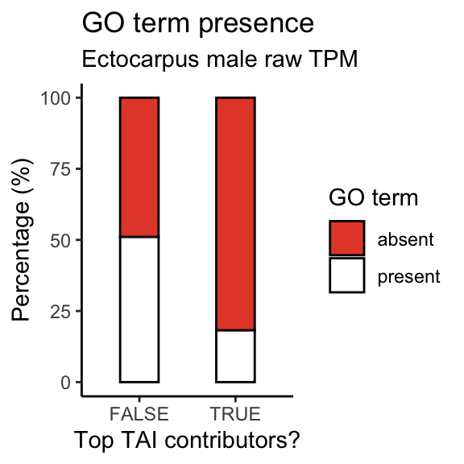

```r
# raw males

pTAI100 <- Ec_PES_32m_unicell %>%
        dplyr::mutate(pTAI100 = 1)

GO_plot_input <- Ec_PES_32m %>%
        dplyr::select(GeneID) %>%
        dplyr::left_join(GO_Ec, by = join_by(GeneID)) %>%
        dplyr::mutate(GO_present = case_when(
                !is.na(GO_term) ~ "present",
                TRUE ~ "absent"
                )) %>%
        dplyr::left_join(pTAI100, by = join_by(GeneID)) %>%
        dplyr::mutate(pTAI100 = case_when(
                pTAI100 == 1 ~ T,
                TRUE ~ F
                )) %>%
        dplyr::select(-GO_term) %>%
        dplyr::distinct()

GO_plot_input %>%
        dplyr::group_by(pTAI100, GO_present) %>%
        dplyr::summarise(count = n()) %>%
        dplyr::group_by(pTAI100) %>%
        dplyr::mutate(perc = count/sum(count)) %>%
        ggplot2::ggplot(aes(x = pTAI100, y = perc*100, fill = GO_present)) +
        ggplot2::geom_col(colour = "black", width = 0.4) +
        ggplot2::scale_fill_manual(values = c("#E64B35FF", "white")) +
        ggplot2::theme_classic() +
        ggplot2::labs(title = "GO term presence",
                      subtitle = "Ectocarpus male raw TPM",
                      fill = "GO term",
                      x = "Top TAI contributors?",
                      y = "Percentage (%)")
```

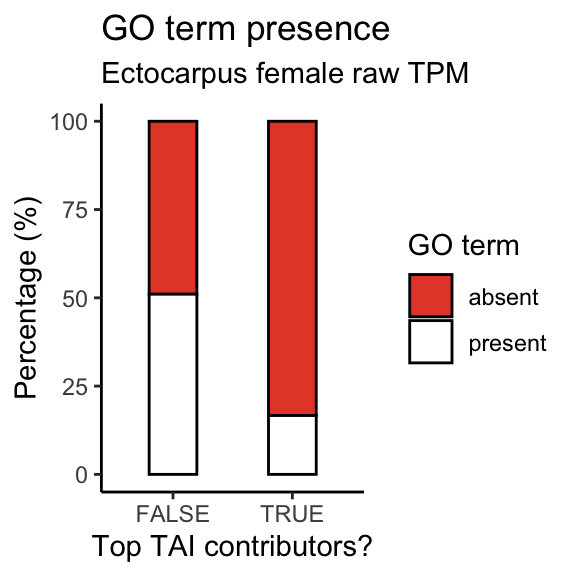

```r
# raw females

pTAI100 <- Ec_PES_25f_unicell %>%
        dplyr::mutate(pTAI100 = 1)

GO_plot_input <- Ec_PES_25f %>%
        dplyr::select(GeneID) %>%
        dplyr::left_join(GO_Ec, by = join_by(GeneID)) %>%
        dplyr::mutate(GO_present = case_when(
                !is.na(GO_term) ~ "present",
                TRUE ~ "absent"
                )) %>%
        dplyr::left_join(pTAI100, by = join_by(GeneID)) %>%
        dplyr::mutate(pTAI100 = case_when(
                pTAI100 == 1 ~ T,
                TRUE ~ F
                )) %>%
        dplyr::select(-GO_term) %>%
        dplyr::distinct()

GO_plot_input %>%
        dplyr::group_by(pTAI100, GO_present) %>%
        dplyr::summarise(count = n()) %>%
        dplyr::group_by(pTAI100) %>%
        dplyr::mutate(perc = count/sum(count)) %>%
        ggplot2::ggplot(aes(x = pTAI100, y = perc*100, fill = GO_present)) +
        ggplot2::geom_col(colour = "black", width = 0.4) +
        ggplot2::scale_fill_manual(values = c("#E64B35FF", "white")) +
        ggplot2::theme_classic() +
        ggplot2::labs(title = "GO term presence",
                      subtitle = "Ectocarpus female raw TPM",
                      fill = "GO term",
                      x = "Top TAI contributors?",
                      y = "Percentage (%)")
```

### sqrt TPM

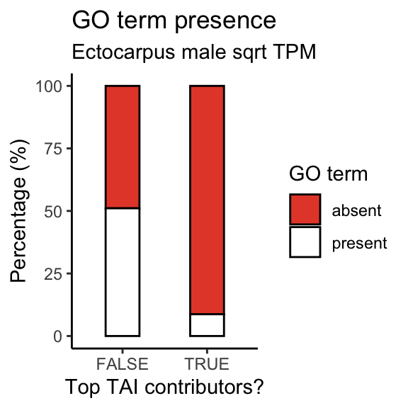

```r
# sqrt males

pTAI100 <- Ec_PES_32m.sqrt_unicell %>%
        dplyr::mutate(pTAI100 = 1)

GO_plot_input <- Ec_PES_32m.sqrt %>%
        dplyr::select(GeneID) %>%
        dplyr::left_join(GO_Ec, by = join_by(GeneID)) %>%
        dplyr::mutate(GO_present = case_when(
                !is.na(GO_term) ~ "present",
                TRUE ~ "absent"
                )) %>%
        dplyr::left_join(pTAI100, by = join_by(GeneID)) %>%
        dplyr::mutate(pTAI100 = case_when(
                pTAI100 == 1 ~ T,
                TRUE ~ F
                )) %>%
        dplyr::select(-GO_term) %>%
        dplyr::distinct()

GO_plot_input %>%
        dplyr::group_by(pTAI100, GO_present) %>%
        dplyr::summarise(count = n()) %>%
        dplyr::group_by(pTAI100) %>%
        dplyr::mutate(perc = count/sum(count)) %>%
        ggplot2::ggplot(aes(x = pTAI100, y = perc*100, fill = GO_present)) +
        ggplot2::geom_col(colour = "black", width = 0.4) +
        ggplot2::scale_fill_manual(values = c("#E64B35FF", "white")) +
        ggplot2::theme_classic() +
        ggplot2::labs(title = "GO term presence",
                      subtitle = "Ectocarpus male sqrt TPM",
                      fill = "GO term",
                      x = "Top TAI contributors?",
                      y = "Percentage (%)")
```

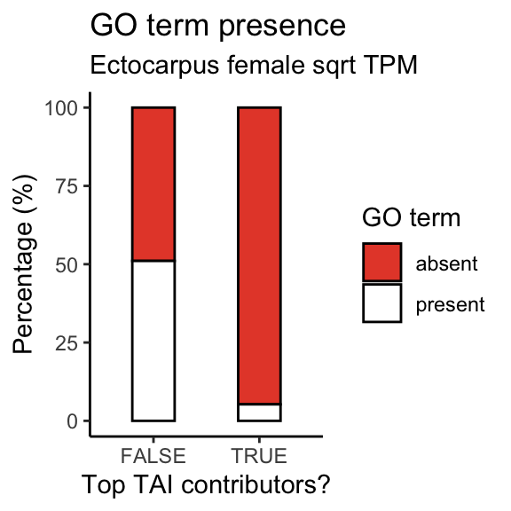

```r
# sqrt females

pTAI100 <- Ec_PES_25f.sqrt_unicell %>%
        dplyr::mutate(pTAI100 = 1)

GO_plot_input <- Ec_PES_25f.sqrt %>%
        dplyr::select(GeneID) %>%
        dplyr::left_join(GO_Ec, by = join_by(GeneID)) %>%
        dplyr::mutate(GO_present = case_when(
                !is.na(GO_term) ~ "present",
                TRUE ~ "absent"
                )) %>%
        dplyr::left_join(pTAI100, by = join_by(GeneID)) %>%
        dplyr::mutate(pTAI100 = case_when(
                pTAI100 == 1 ~ T,
                TRUE ~ F
                )) %>%
        dplyr::select(-GO_term) %>%
        dplyr::distinct()

GO_plot_input %>%
        dplyr::group_by(pTAI100, GO_present) %>%
        dplyr::summarise(count = n()) %>%
        dplyr::group_by(pTAI100) %>%
        dplyr::mutate(perc = count/sum(count)) %>%
        ggplot2::ggplot(aes(x = pTAI100, y = perc*100, fill = GO_present)) +
        ggplot2::geom_col(colour = "black", width = 0.4) +
        ggplot2::scale_fill_manual(values = c("#E64B35FF", "white")) +
        ggplot2::theme_classic() +
        ggplot2::labs(title = "GO term presence",
                      subtitle = "Ectocarpus female sqrt TPM",
                      fill = "GO term",
                      x = "Top TAI contributors?",
                      y = "Percentage (%)")
```

## What is the proportion of genes without interproscan results?

### sqrt TPM

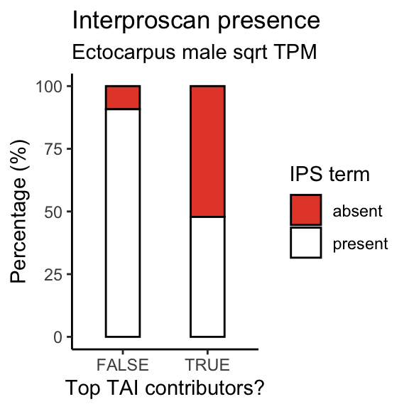

```r
# sqrt males

pTAI100 <- Ec_PES_32m.sqrt_unicell %>%
        dplyr::mutate(pTAI100 = 1)

IPR_plot_input <- Ec_PES_32m.sqrt %>%
        dplyr::select(GeneID) %>%
        dplyr::left_join(IPR_Ec, by = join_by(GeneID)) %>%
        dplyr::mutate(IPR_present = case_when(
                !is.na(Analysis) ~ "present",
                TRUE ~ "absent"
                )) %>%
        dplyr::left_join(pTAI100, by = join_by(GeneID)) %>%
        dplyr::mutate(pTAI100 = case_when(
                pTAI100 == 1 ~ T,
                TRUE ~ F
                )) %>%
        dplyr::select(-c(GO_term, Analysis, Signature_description)) %>%
        dplyr::distinct()

IPR_plot_input %>%
        dplyr::group_by(pTAI100, IPR_present) %>%
        dplyr::summarise(count = n()) %>%
        dplyr::group_by(pTAI100) %>%
        dplyr::mutate(perc = count/sum(count)) %>%
        ggplot2::ggplot(aes(x = pTAI100, y = perc*100, fill = IPR_present)) +
        ggplot2::geom_col(colour = "black", width = 0.4) +
        ggplot2::scale_fill_manual(values = c("#E64B35FF", "white")) +
        ggplot2::theme_classic() +
        ggplot2::labs(title = "Interproscan presence",
                      subtitle = "Ectocarpus male sqrt TPM",
                      fill = "IPS term",
                      x = "Top TAI contributors?",
                      y = "Percentage (%)")
```

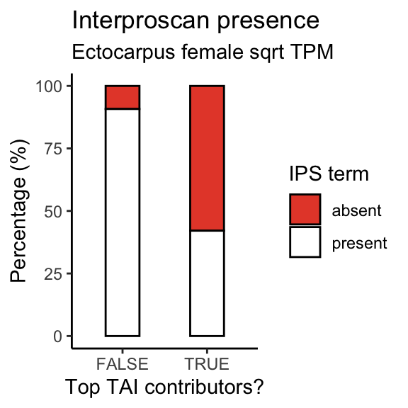

```r
# sqrt females

pTAI100 <- Ec_PES_25f.sqrt_unicell %>%
        dplyr::mutate(pTAI100 = 1)

IPR_plot_input <- Ec_PES_25f.sqrt %>%
        dplyr::select(GeneID) %>%
        dplyr::left_join(IPR_Ec, by = join_by(GeneID)) %>%
        dplyr::mutate(IPR_present = case_when(
                !is.na(Analysis) ~ "present",
                TRUE ~ "absent"
                )) %>%
        dplyr::left_join(pTAI100, by = join_by(GeneID)) %>%
        dplyr::mutate(pTAI100 = case_when(
                pTAI100 == 1 ~ T,
                TRUE ~ F
                )) %>%
        dplyr::select(-c(GO_term, Analysis, Signature_description)) %>%
        dplyr::distinct()

IPR_plot_input %>%
        dplyr::group_by(pTAI100, IPR_present) %>%
        dplyr::summarise(count = n()) %>%
        dplyr::group_by(pTAI100) %>%
        dplyr::mutate(perc = count/sum(count)) %>%
        ggplot2::ggplot(aes(x = pTAI100, y = perc*100, fill = IPR_present)) +
        ggplot2::geom_col(colour = "black", width = 0.4) +
        ggplot2::scale_fill_manual(values = c("#E64B35FF", "white")) +
        ggplot2::theme_classic() +
        ggplot2::labs(title = "Interproscan presence",
                      subtitle = "Ectocarpus female sqrt TPM",
                      fill = "IPS term",
                      x = "Top TAI contributors?",
                      y = "Percentage (%)")
```

## What is the proportion of genes with `consensus disorder prediction`?

```r
POI <- c("consensus disorder prediction") # property of interest

IPR_Ec_disorder <- IPR_Ec[IPR_Ec$Signature_description %in% POI, ] %>%
        dplyr::select(GeneID) %>%
        dplyr::distinct() %>%
        dplyr::mutate(POI = 1)
```

### raw TPM

```r
# raw males

pTAI100 <- Ec_PES_32m_unicell %>%
        dplyr::mutate(pTAI100 = 1)

POI_fisher_input <- Ec_PES_32m %>%
        dplyr::select(GeneID) %>%
        dplyr::left_join(IPR_Ec_disorder, by = join_by(GeneID)) %>%
        dplyr::mutate(POI_present = case_when(
                !is.na(POI) ~ "POI_present",
                TRUE ~ "POI_notpresent"
                )) %>%
        dplyr::left_join(pTAI100, by = join_by(GeneID)) %>%
        dplyr::mutate(pTAI100 = case_when(
                pTAI100 == 1 ~ "top TAI contributors",
                TRUE ~ "not top TAI contributors"
                ))

fisher.test(POI_fisher_input$pTAI100, POI_fisher_input$POI_present, alternative = "greater")
```

```
##
##  Fisher's Exact Test for Count Data
##
## data:  POI_fisher_input$pTAI100 and POI_fisher_input$POI_present
## p-value = 0.998
## alternative hypothesis: true odds ratio is greater than 1
## 95 percent confidence interval:
##  0.1352825       Inf
## sample estimates:
## odds ratio
##  0.3182553
```

```r
chisq.test(POI_fisher_input$pTAI100, POI_fisher_input$POI_present)
```

```
##
##  Pearson's Chi-squared test with Yates' continuity correction
##
## data:  POI_fisher_input$pTAI100 and POI_fisher_input$POI_present
## X-squared = 6.2546, df = 1, p-value = 0.01239
```

```r
table(POI_fisher_input$pTAI100, POI_fisher_input$POI_present)
```

```
##
##                            POI_notpresent POI_present
##   not top TAI contributors           4131        7418
##   top TAI contributors                 14           8
```

```r
# raw females

pTAI100 <- Ec_PES_25f_unicell %>%
        dplyr::mutate(pTAI100 = 1)

POI_fisher_input <- Ec_PES_25f %>%
        dplyr::select(GeneID) %>%
        dplyr::left_join(IPR_Ec_disorder, by = join_by(GeneID)) %>%
        dplyr::mutate(POI_present = case_when(
                !is.na(POI) ~ "POI_present",
                TRUE ~ "POI_notpresent"
                )) %>%
        dplyr::left_join(pTAI100, by = join_by(GeneID)) %>%
        dplyr::mutate(pTAI100 = case_when(
                pTAI100 == 1 ~ "top TAI contributors",
                TRUE ~ "not top TAI contributors"
                ))

fisher.test(POI_fisher_input$pTAI100, POI_fisher_input$POI_present, alternative = "greater")
```

```
##
##  Fisher's Exact Test for Count Data
##
## data:  POI_fisher_input$pTAI100 and POI_fisher_input$POI_present
## p-value = 0.9924
## alternative hypothesis: true odds ratio is greater than 1
## 95 percent confidence interval:
##  0.138305      Inf
## sample estimates:
## odds ratio
##  0.3546263
```

```r
chisq.test(POI_fisher_input$pTAI100, POI_fisher_input$POI_present)
```

```
##
##  Pearson's Chi-squared test with Yates' continuity correction
##
## data:  POI_fisher_input$pTAI100 and POI_fisher_input$POI_present
## X-squared = 3.9738, df = 1, p-value = 0.04621
```

```r
table(POI_fisher_input$pTAI100, POI_fisher_input$POI_present)
```

```
##
##                            POI_notpresent POI_present
##   not top TAI contributors           4134        7419
##   top TAI contributors                 11           7
```

### sqrt TPM

```r
# sqrt males

pTAI100 <- Ec_PES_32m.sqrt_unicell %>%
        dplyr::mutate(pTAI100 = 1)

POI_fisher_input <- Ec_PES_32m.sqrt %>%
        dplyr::select(GeneID) %>%
        dplyr::left_join(IPR_Ec_disorder, by = join_by(GeneID)) %>%
        dplyr::mutate(POI_present = case_when(
                !is.na(POI) ~ "POI_present",
                TRUE ~ "POI_notpresent"
                )) %>%
        dplyr::left_join(pTAI100, by = join_by(GeneID)) %>%
        dplyr::mutate(pTAI100 = case_when(
                pTAI100 == 1 ~ "top TAI contributors",
                TRUE ~ "not top TAI contributors"
                ))

fisher.test(POI_fisher_input$pTAI100, POI_fisher_input$POI_present, alternative = "greater")
```

```
##
##  Fisher's Exact Test for Count Data
##
## data:  POI_fisher_input$pTAI100 and POI_fisher_input$POI_present
## p-value = 0.9961
## alternative hypothesis: true odds ratio is greater than 1
## 95 percent confidence interval:
##  0.158479      Inf
## sample estimates:
## odds ratio
##  0.3580811
```

```r
chisq.test(POI_fisher_input$pTAI100, POI_fisher_input$POI_present)
```

```
##
##  Pearson's Chi-squared test with Yates' continuity correction
##
## data:  POI_fisher_input$pTAI100 and POI_fisher_input$POI_present
## X-squared = 5.2446, df = 1, p-value = 0.02201
```

```r
table(POI_fisher_input$pTAI100, POI_fisher_input$POI_present)
```

```
##
##                            POI_notpresent POI_present
##   not top TAI contributors           4131        7417
##   top TAI contributors                 14           9
```

```r
# sqrt females

pTAI100 <- Ec_PES_25f.sqrt_unicell %>%
        dplyr::mutate(pTAI100 = 1)

POI_fisher_input <- Ec_PES_25f.sqrt %>%
        dplyr::select(GeneID) %>%
        dplyr::left_join(IPR_Ec_disorder, by = join_by(GeneID)) %>%
        dplyr::mutate(POI_present = case_when(
                !is.na(POI) ~ "POI_present",
                TRUE ~ "POI_notpresent"
                )) %>%
        dplyr::left_join(pTAI100, by = join_by(GeneID)) %>%
        dplyr::mutate(pTAI100 = case_when(
                pTAI100 == 1 ~ "top TAI contributors",
                TRUE ~ "not top TAI contributors"
                ))

fisher.test(POI_fisher_input$pTAI100, POI_fisher_input$POI_present, alternative = "greater")
```

```
##
##  Fisher's Exact Test for Count Data
##
## data:  POI_fisher_input$pTAI100 and POI_fisher_input$POI_present
## p-value = 0.9998
## alternative hypothesis: true odds ratio is greater than 1
## 95 percent confidence interval:
##  0.06867542        Inf
## sample estimates:
## odds ratio
##  0.1988384
```

```r
chisq.test(POI_fisher_input$pTAI100, POI_fisher_input$POI_present)
```

```
##
##  Pearson's Chi-squared test with Yates' continuity correction
##
## data:  POI_fisher_input$pTAI100 and POI_fisher_input$POI_present
## X-squared = 10.275, df = 1, p-value = 0.001349
```

```r
table(POI_fisher_input$pTAI100, POI_fisher_input$POI_present)
```

```
##
##                            POI_notpresent POI_present
##   not top TAI contributors           4131        7421
##   top TAI contributors                 14           5
```

The genes with `consensus disorder prediction` are not significantly enriched.

## Summary

```
Male:
GO:0009765 (photosynthesis, light harvesting)
GO:0016020 (membrane)
GO:0046872 (metal ion binding)
GO:0071203 (WASH complex)
GO:0016813 (hydrolase activity, acting on carbon-nitrogen (but not peptide) bonds, in linear amidines)

Female:
GO:0046872 (metal ion binding)
GO:0071203 (WASH complex)
GO:0016813 (hydrolase activity, acting on carbon-nitrogen (but not peptide) bonds, in linear amidines)
```

It is interesting to see that membrane-related GOs are represented, particularly because some studies suggest transmembrane proteins to have evolved *de novo* multiple times. Moreover, many genes driving the TAI have no annotations and this is signficant (i.e. significantly enriched for genes without GO annotations). Those that do have annotations are overwhelmingly detected as `consensus disorder prediction`, though this prediction is not enriched compared to the background. Between males and females, it is reassuring that the pTAI genes are so similar.

The “Mollusc metallothionein signature” is interesting because that is the reason why “metal ion binding” comes up. Is this a contamination? A blast search reveals no other hits in the NR except in *Ectocarpus* and *Fucus vesiculosus*. There is no domain like this in the *Ectocarpus* genome aside from this gene so this is interesting.

From this analysis, it appears to me that the raw TPM or sqrt is probably best for the analysis because the expression values matter more than the PS in determining the TAI. Thus, older PS can be seen as shared contributors, as opposed to the extreme case of the rank transformation.

I initially planned to do a GO enrichment analysis but with most genes being novel genes without homologues, it was probably difficult to match domains etc. with known homologues.